# Práctica 1: Análisis descriptivo de las estadísticas de Pokémon

Estadística - Curso 2024/2025

Grupo 2:** Paula Armenteros, Marta de Miguel, Victor Gil, María Fernanda Montero, Daniel Redondo.

# 1. Introducción y definición de objetivos

En este estudio se analizarán datos obtenidos de “smogon” y “kaggle” que recogen las estadísticas y usabilidad de cada Pokémon desde la primera hasta la octava generación.

Los objetivos de este análisis se centrarán en:

1. Determinar la variación de las estadísticas de los Pokémon entre generaciones. Con esto, se busca analizar la variación de HP, Attack, Defense, Sp_attack, Sp_defense y Speed; y analizar cómo está repartida la suma de estas estadísticas entre todos los Pokémon.
2. Determinar la variación de tipos de Pokémon entre generaciones. Se busca determinar la variación entre tipos en distintas generaciones, para ver tendencias y comprender cómo ha variado la forma de elegir los tipos de cada Pokémon. También se estudiarán los tipos más usados en la escena competitiva.
3. Determinar la variación de la cantidad de Pokémon legendarios entre generaciones. Ayudará a comprender la tendencia que están tomando los juegos de la saga Pokémon según avanza a la hora de introducir nuevos Pokémon legendarios en cada juego.
4. Comprobar la posibilidad de existencia de correlaciones entre estadísticas de cualidades similares. Es decir, verificar si estadísticas como Attack y Defense, influyen de alguna manera en las estadísticas Sp_attack y Sp_defense respectivamente en cada Pokémon. Además de, encontrar una relación entre el uso de cada Pokémon en la escena competitiva con respecto a su media de estadísticas.

Una vez recogidos todos estos datos, los siguientes objetivos se centrarán en:

5. Concluir cuáles son los Pokémons más usados en el ámbito competitivo y sus motivos. Se quiere definir qué factores pueden influir a la hora de usar un Pokémon en la escena competitiva del juego.
6. Elaborar una predicción sobre la novena generación de Pokémon. Una vez analizada la progresión en las distintas variables por cada generación, ver qué tendencia están tomando para formular lo que se espera para una posible novena generación.

# 2. Importación de datos y carga de paquetes

```r
library(readxl)
```

```r
library(tidyverse)
library(summarytools)
library(ggplot2)
library(knitr)
library('dplyr')


pokemon <- read_excel("data/PokemonV4.xlsx")
```

# 3. Diccionario de datos

- **`Number:`** Número identificador del Pokémon en la Pokédex Nacional.
  - Variable tipo: Identificador.
- **`Name:`** Nombre del Pokémon.
  - Variable tipo: Categórica multinivel.
- **`Type_1:`** El primer tipo elemental del Pokémon.
  - Variable tipo: Categórica multinivel.
- **`Type_2:`** El segundo tipo opcional elemental del Pokémon.
  - Variable tipo: Categórica multinivel.
- **`Total:`** La suma de las estadísticas del Pokémon.
  - Variable tipo: Numérica discreta.
- **`HP:`** Los puntos de salud del Pokémon.
  - Variable tipo: Numérica discreta.
- **`Attack:`** Los puntos de ataque físico del Pokémon.
  - Variable tipo: Numérica discreta.
- **`Defense:`** Los puntos de defensa física del Pokémon.
  - Variable tipo: Numérica discreta.
- **`Sp_attack:`** Los puntos de ataque especial del Pokémon.
  - Variable tipo: Numérica discreta.
- **`Sp_defense:`** Los puntos de defensa especial del Pokémon.
  - Variable tipo: Numérica discreta.
- **`Speed:`** Los puntos de velocidad del Pokémon.
  - Variable tipo: Numérica discreta.
- **`Stat_Average:`** La media de las estadísticas del Pokémon.
  - Variable tipo: Numérica continua.
- **`Generation:`** La generación de juegos a la que pertenece el Pokémon.
  - Variable tipo: Categórica ordinal.
- **`Legendary:`** Si el Pokémon es legendario o no (YES/NO).
  - Variable tipo: Categórica dicotómica.
- **`Double_Type:`** Si el Pokémon tiene dos tipos o no (YES/NO).
  - Variable tipo: Categórica dicotómica.
- **`Usage_Percentage:`** Porcentaje de uso de cada Pokémon en torneos competitivos.
  - Variable tipo: Numérica continua.

# 4. Análisis exploratorio de datos

## 4.1 Datos univariantes

### Tablas de frecuencias e histogramas

#### Tabla de frecuencia de intervalos del total de estadísticas

```r
# Transformamos el dataframe pokemon creando una nueva columna llamada " intervalos_totales" que creara 20 intervalos del dato total.
pokemon <- pokemon |>
  mutate(intervalos_totales = cut(Total, breaks = 20))

# Creamos una tabla de frecuencias a partir del dataframe pokemon.
tabla_frecuencias <- pokemon|>
# Contamos los intervalos que hay y creamos la frecuencia relativa, la frecuencia acumulada, la frecuencia relativa acumulada.
 count(intervalos_totales) |>
  mutate(f = n/nrow(pokemon),
   N = cumsum(n),
    F = cumsum(f))
#Pintamos y definimos el número de decimales queremos que tenga nuestra tabla
knitr::kable(tabla_frecuencias, digits = 3)
```

| intervalos_totales | n | f | N | F |
| --- | --- | --- | --- | --- |
| (174,222] | 30 | 0.028 | 30 | 0.028 |
| (222,270] | 55 | 0.051 | 85 | 0.079 |
| (270,318] | 138 | 0.129 | 223 | 0.208 |
| (318,365] | 112 | 0.104 | 335 | 0.312 |
| (365,412] | 92 | 0.086 | 427 | 0.398 |
| (412,460] | 109 | 0.102 | 536 | 0.500 |
| (460,508] | 232 | 0.216 | 768 | 0.716 |
| (508,555] | 138 | 0.129 | 906 | 0.845 |
| (555,602] | 102 | 0.095 | 1008 | 0.940 |
| (602,650] | 17 | 0.016 | 1025 | 0.956 |
| (650,698] | 27 | 0.025 | 1052 | 0.981 |
| (698,745] | 13 | 0.012 | 1065 | 0.993 |
| (745,792] | 6 | 0.006 | 1071 | 0.999 |
| (1.08e+03,1.13e+03] | 1 | 0.001 | 1072 | 1.000 |

Observamos que la mayor parte de los datos se concentra en los intervalos (270-508), ya que los intervalos con mayor frecuencia relativa se encuentran en este rango. A partir del intervalo (555-602), los datos comienzan a disminuir significativamente, lo que indica que los valores más altos son mucho menos comunes en esta distribución.

#### Histograma de total

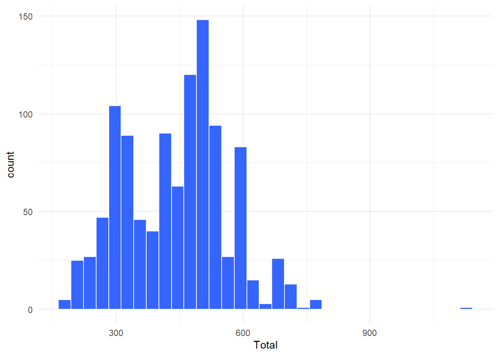

```r
# Creamos un histograma a partir de los datos Total.
pokemon |> ggplot(aes(Total)) +
# Definimos el color y el número de barras que tendrá nuestro histograma. Calculamos el número de barras a través de la raíz cuadrada de nuestro número de datos.
  geom_histogram(fill = "#3565fc", bins = 33, col = "white") +
# Indicamos el tema.
  theme_minimal()
```

Podemos observar que la mayoría de las estadísticas de los Pokémon se encuentran dentro del rango de 300 a 500, con un pico más pronunciado entre 500 y 600. Además, notamos que solo hay un Pokémon cuya estadística total supera los 1000, situándose fuera de estos rangos.

#### Tabla de frecuencia de intervalos de HP

```r
# Transformamos el dataframe pokemon creando una nueva columna llamada " intervalos_HP" que creara 20 intervalos del dato HP.
pokemon <- pokemon |>
  mutate(intervalos_HP = cut(HP, breaks = 20))

# Creamos una tabla de frecuencias a partir del dataframe pokemon.
tabla_frecuencias <- pokemon|>
# Contamos los intervalos que hay y creamos la frecuencia relativa, la frecuencia acumulada, la frecuencia relativa acumulada.
 count(intervalos_HP) |>
  mutate(f = n/nrow(pokemon),
   N = cumsum(n),
    F = cumsum(f))
#Pintamos y definimos el número de decimales queremos que tenga nuestra tabla
knitr::kable(tabla_frecuencias, digits = 3)
```

| intervalos_HP | n | f | N | F |
| --- | --- | --- | --- | --- |
| (0.746,13.7] | 3 | 0.003 | 3 | 0.003 |
| (13.7,26.4] | 10 | 0.009 | 13 | 0.012 |
| (26.4,39.1] | 52 | 0.049 | 65 | 0.061 |
| (39.1,51.8] | 207 | 0.193 | 272 | 0.254 |
| (51.8,64.5] | 190 | 0.177 | 462 | 0.431 |
| (64.5,77.2] | 256 | 0.239 | 718 | 0.670 |
| (77.2,89.9] | 119 | 0.111 | 837 | 0.781 |
| (89.9,103] | 142 | 0.132 | 979 | 0.913 |
| (103,115] | 50 | 0.047 | 1029 | 0.960 |
| (115,128] | 16 | 0.015 | 1045 | 0.975 |
| (128,141] | 11 | 0.010 | 1056 | 0.985 |
| (141,153] | 5 | 0.005 | 1061 | 0.990 |
| (153,166] | 3 | 0.003 | 1064 | 0.993 |
| (166,179] | 1 | 0.001 | 1065 | 0.993 |
| (179,192] | 1 | 0.001 | 1066 | 0.994 |
| (192,204] | 1 | 0.001 | 1067 | 0.995 |
| (204,217] | 1 | 0.001 | 1068 | 0.996 |
| (217,230] | 1 | 0.001 | 1069 | 0.997 |
| (242,255] | 3 | 0.003 | 1072 | 1.000 |

En esta tabla podemos ver que el valor más común de HP se encuentra entre 64.5 y 77.2, con un total de 256 Pokémon. Los valores más bajos de HP son menos comunes, ya que hay pocos Pokémon con un valor por debajo de 14.

#### Histograma de HP

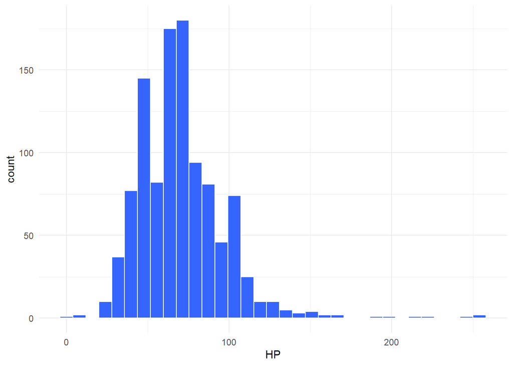

```r
# Creamos un histograma a partir de los datos HP.
pokemon |> ggplot(aes(HP)) +
# Definimos el color y el número de barras que tendrá nuestro histograma. Calculamos el número de barras a través de la raíz cuadrada de nuestro número de datos.
  geom_histogram(fill = "#3565fc", bins = 33, col = "white") +
# Indicamos el tema.
  theme_minimal()
```

#### Tabla de frecuencia de intervalos de Attack

```r
# Transformamos el dataframe pokemon creando una nueva columna llamada " intervalos_Attack" que creara 20 intervalos de Attack.
pokemon <- pokemon |>
  mutate(intervalos_Attack = cut(Attack, breaks = 20))

# Creamos una tabla de frecuencias a partir del dataframe pokemon.
tabla_frecuencias <- pokemon|>
# Contamos los intervalos que hay y creamos la frecuencia relativa, la frecuencia acumulada, la frecuencia relativa acumulada.
 count(intervalos_Attack) |>
  mutate(f = n/nrow(pokemon),
   N = cumsum(n),
    F = cumsum(f))
#Pintamos y definimos el número de decimales queremos que tenga nuestra tabla
knitr::kable(tabla_frecuencias, digits = 3)
```

| intervalos_Attack | n | f | N | F |
| --- | --- | --- | --- | --- |
| (4.82,14.2] | 5 | 0.005 | 5 | 0.005 |
| (14.2,23.5] | 13 | 0.012 | 18 | 0.017 |
| (23.5,32.8] | 37 | 0.035 | 55 | 0.051 |
| (32.8,42] | 57 | 0.053 | 112 | 0.104 |
| (42,51.2] | 96 | 0.090 | 208 | 0.194 |
| (51.2,60.5] | 118 | 0.110 | 326 | 0.304 |
| (60.5,69.8] | 94 | 0.088 | 420 | 0.392 |
| (69.8,79] | 111 | 0.104 | 531 | 0.495 |
| (79,88.2] | 130 | 0.121 | 661 | 0.617 |
| (88.2,97.5] | 97 | 0.090 | 758 | 0.707 |
| (97.5,107] | 92 | 0.086 | 850 | 0.793 |
| (107,116] | 58 | 0.054 | 908 | 0.847 |
| (116,125] | 64 | 0.060 | 972 | 0.907 |
| (125,134] | 37 | 0.035 | 1009 | 0.941 |
| (134,144] | 21 | 0.020 | 1030 | 0.961 |
| (144,153] | 18 | 0.017 | 1048 | 0.978 |
| (153,162] | 9 | 0.008 | 1057 | 0.986 |
| (162,172] | 9 | 0.008 | 1066 | 0.994 |
| (172,181] | 3 | 0.003 | 1069 | 0.997 |
| (181,190] | 3 | 0.003 | 1072 | 1.000 |

En esta tabla, el Attack se distribuye de manera bastante uniforme en los intervalos intermedios. El intervalo (79-88.2) tiene el mayor número de Pokémon, con un total de 130. Los valores de Attack muy bajos o muy altos son raros, ya que hay pocos Pokémon en esos extremos.

#### Histograma de Attack

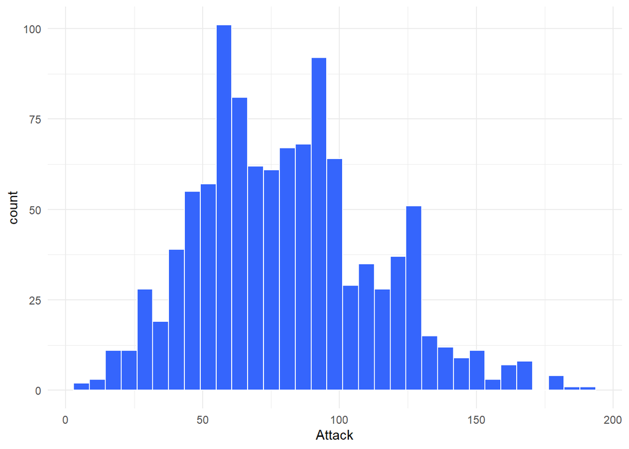

```r
# Creamos un histograma a partir de los datos Attack.
pokemon |> ggplot(aes(Attack)) +
# Definimos el color y el número de barras que tendrá nuestro histograma. Calculamos el número de barras a través de la raíz cuadrada de nuestro número de datos.
  geom_histogram(fill = "#3565fc", bins = 33, col = "white") +
# Indicamos el tema.
  theme_minimal()
```

#### Tabla de frecuencia de intervalos de Defense

```r
# Transformamos el dataframe pokemon creando una nueva columna llamada " intervalos_Defense" que creara 20 intervalos de Defense.
pokemon <- pokemon |>
  mutate(intervalos_Defense = cut(Defense, breaks = 20))

# Creamos una tabla de frecuencias a partir del dataframe pokemon.
tabla_frecuencias <- pokemon|>
# Contamos los intervalos que hay y creamos la frecuencia relativa, la frecuencia acumulada, la frecuencia relativa acumulada.
 count(intervalos_Defense) |>
  mutate(f = n/nrow(pokemon),
   N = cumsum(n),
    F = cumsum(f))
#Pintamos y definimos el número de decimales queremos que tenga nuestra tabla
knitr::kable(tabla_frecuencias, digits = 3)
```

| intervalos_Defense | n | f | N | F |
| --- | --- | --- | --- | --- |
| (4.75,17.2] | 7 | 0.007 | 7 | 0.007 |
| (17.2,29.5] | 11 | 0.010 | 18 | 0.017 |
| (29.5,41.8] | 115 | 0.107 | 133 | 0.124 |
| (41.8,54] | 149 | 0.139 | 282 | 0.263 |
| (54,66.2] | 200 | 0.187 | 482 | 0.450 |
| (66.2,78.5] | 157 | 0.146 | 639 | 0.596 |
| (78.5,90.8] | 166 | 0.155 | 805 | 0.751 |
| (90.8,103] | 98 | 0.091 | 903 | 0.842 |
| (103,115] | 68 | 0.063 | 971 | 0.906 |
| (115,128] | 40 | 0.037 | 1011 | 0.943 |
| (128,140] | 24 | 0.022 | 1035 | 0.965 |
| (140,152] | 22 | 0.021 | 1057 | 0.986 |
| (152,164] | 3 | 0.003 | 1060 | 0.989 |
| (164,176] | 1 | 0.001 | 1061 | 0.990 |
| (176,189] | 4 | 0.004 | 1065 | 0.993 |
| (189,201] | 2 | 0.002 | 1067 | 0.995 |
| (201,213] | 1 | 0.001 | 1068 | 0.996 |
| (226,238] | 3 | 0.003 | 1071 | 0.999 |
| (238,250] | 1 | 0.001 | 1072 | 1.000 |

En esta tabla podemos observar que la mayor parte de los datos está concentrada entre los intervalos (41.8-90.8). A partir de valores mayores a 128, los datos se vuelven muy poco comunes, lo que indica que estos valores son extremadamente raros.

#### Histograma de Defense

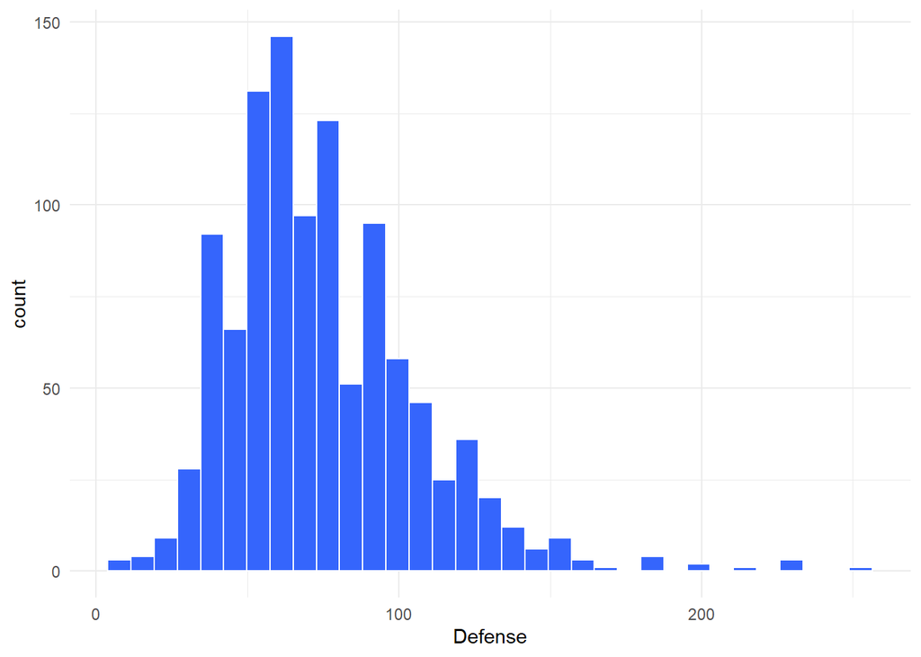

```r
# Creamos un histograma a partir de los datos Defense.
pokemon |> ggplot(aes(Defense)) +
# Definimos el color y el número de barras que tendrá nuestro histograma. Calculamos el número de barras a través de la raíz cuadrada de nuestro número de datos.
  geom_histogram(fill = "#3565fc", bins = 33, col = "white") +
# Indicamos el tema.
  theme_minimal()
```

#### Tabla de frecuencia de intervalos de Sp_attack

```r
# Transformamos el dataframe pokemon creando una nueva columna llamada " intervalos_Sp_attack" que creara 20 intervalos de Sp_attack.
pokemon <- pokemon |>
  mutate(intervalos_Sp_attack = cut(Sp_attack, breaks = 20))

# Creamos una tabla de frecuencias a partir del dataframe pokemon.
tabla_frecuencias <- pokemon|>
# Contamos los intervalos que hay y creamos la frecuencia relativa, la frecuencia acumulada, la frecuencia relativa acumulada.
 count(intervalos_Sp_attack) |>
  mutate(f = n/nrow(pokemon),
   N = cumsum(n),
    F = cumsum(f))
#Pintamos y definimos el número de decimales queremos que tenga nuestra tabla
knitr::kable(tabla_frecuencias, digits = 3)
```

| intervalos_Sp_attack | n | f | N | F |
| --- | --- | --- | --- | --- |
| (9.82,19.2] | 9 | 0.008 | 9 | 0.008 |
| (19.2,28.4] | 30 | 0.028 | 39 | 0.036 |
| (28.4,37.6] | 79 | 0.074 | 118 | 0.110 |
| (37.6,46.8] | 129 | 0.120 | 247 | 0.230 |
| (46.8,56] | 137 | 0.128 | 384 | 0.358 |
| (56,65.2] | 158 | 0.147 | 542 | 0.506 |
| (65.2,74.4] | 69 | 0.064 | 611 | 0.570 |
| (74.4,83.6] | 95 | 0.089 | 706 | 0.659 |
| (83.6,92.8] | 80 | 0.075 | 786 | 0.733 |
| (92.8,102] | 96 | 0.090 | 882 | 0.823 |
| (102,111] | 55 | 0.051 | 937 | 0.874 |
| (111,120] | 35 | 0.033 | 972 | 0.907 |
| (120,130] | 27 | 0.025 | 999 | 0.932 |
| (130,139] | 30 | 0.028 | 1029 | 0.960 |
| (139,148] | 13 | 0.012 | 1042 | 0.972 |
| (148,157] | 14 | 0.013 | 1056 | 0.985 |
| (157,166] | 6 | 0.006 | 1062 | 0.991 |
| (166,176] | 6 | 0.006 | 1068 | 0.996 |
| (176,185] | 3 | 0.003 | 1071 | 0.999 |
| (185,194] | 1 | 0.001 | 1072 | 1.000 |

La mayor parte de los datos está concentrada en los intervalos (37.6-83.6). Los valores mayores de 111 son mucho menos comunes y, al igual que en las otras tablas, a partir de 130 los valores se vuelven prácticamente inexistentes.

#### Histograma de Sp_attack

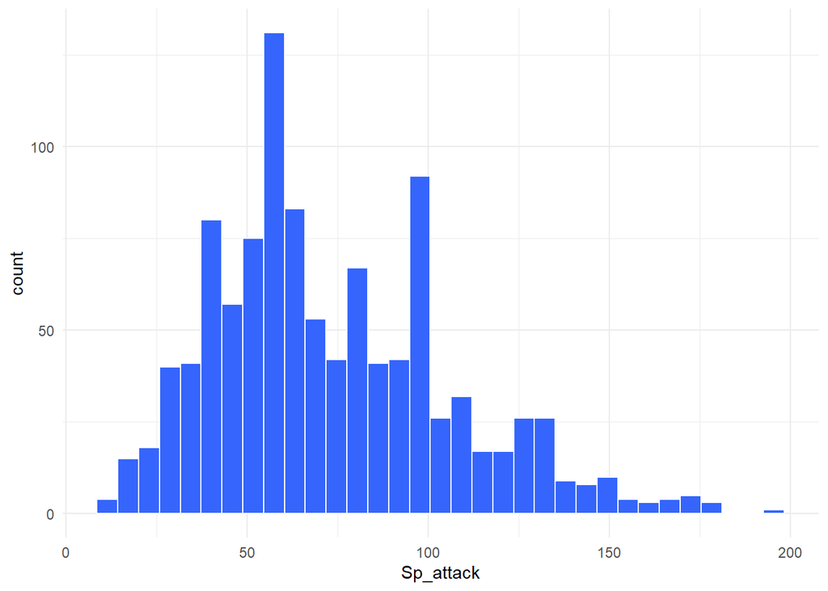

```r
# Creamos un histograma a partir de los datos Sp_attack.
pokemon |> ggplot(aes(Sp_attack)) +
# Definimos el color y el número de barras que tendrá nuestro histograma. Calculamos el número de barras a través de la raíz cuadrada de nuestro número de datos.
  geom_histogram(fill = "#3565fc", bins = 33, col = "white") +
# Indicamos el tema.
  theme_minimal()
```

#### Tabla de frecuencia de intervalos de Sp_defense

```r
# Transformamos el dataframe pokemon creando una nueva columna llamada " intervalos_Sp_defense" que creara 20 intervalos de Sp_defense.
pokemon <- pokemon |>
  mutate(intervalos_Sp_defense = cut(Sp_defense, breaks = 20))

# Creamos una tabla de frecuencias a partir del dataframe pokemon.
tabla_frecuencias <- pokemon|>
# Contamos los intervalos que hay y creamos la frecuencia relativa, la frecuencia acumulada, la frecuencia relativa acumulada.
 count(intervalos_Sp_defense) |>
  mutate(f = n/nrow(pokemon),
   N = cumsum(n),
    F = cumsum(f))
#Pintamos y definimos el número de decimales queremos que tenga nuestra tabla
knitr::kable(tabla_frecuencias, digits = 3)
```

| intervalos_Sp_defense | n | f | N | F |
| --- | --- | --- | --- | --- |
| (19.8,31.5] | 50 | 0.047 | 50 | 0.047 |
| (31.5,43] | 94 | 0.088 | 144 | 0.134 |
| (43,54.5] | 148 | 0.138 | 292 | 0.272 |
| (54.5,66] | 210 | 0.196 | 502 | 0.468 |
| (66,77.5] | 145 | 0.135 | 647 | 0.604 |
| (77.5,89] | 137 | 0.128 | 784 | 0.731 |
| (89,100] | 143 | 0.133 | 927 | 0.865 |
| (100,112] | 58 | 0.054 | 985 | 0.919 |
| (112,124] | 39 | 0.036 | 1024 | 0.955 |
| (124,135] | 28 | 0.026 | 1052 | 0.981 |
| (135,146] | 5 | 0.005 | 1057 | 0.986 |
| (146,158] | 10 | 0.009 | 1067 | 0.995 |
| (158,170] | 2 | 0.002 | 1069 | 0.997 |
| (192,204] | 1 | 0.001 | 1070 | 0.998 |
| (227,238] | 1 | 0.001 | 1071 | 0.999 |
| (238,250] | 1 | 0.001 | 1072 | 1.000 |

#### Histograma de Sp_defense

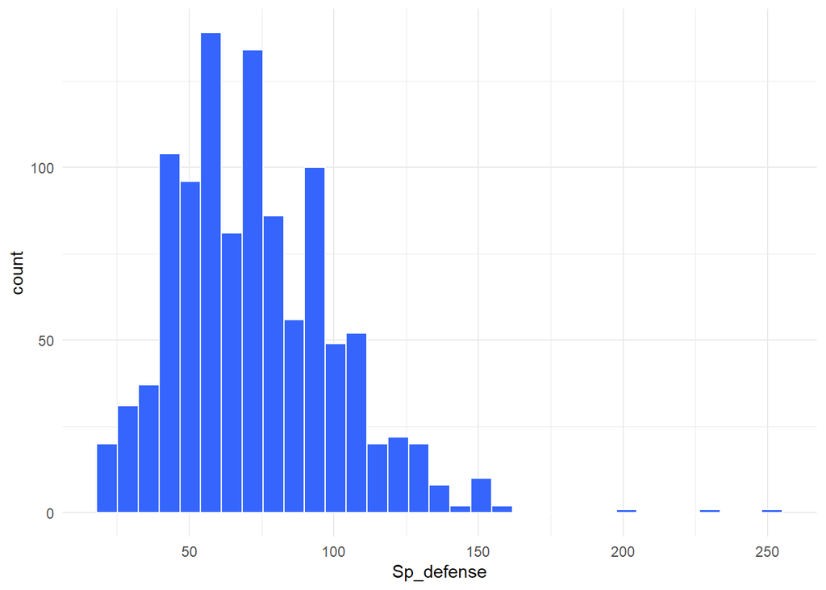

```r
# Creamos un histograma a partir de los datos Sp_defense.
pokemon |> ggplot(aes(Sp_defense)) +
# Definimos el color y el número de barras que tendrá nuestro histograma. Calculamos el número de barras a través de la raíz cuadrada de nuestro número de datos.
  geom_histogram(fill = "#3565fc", bins = 33, col = "white") +
# Indicamos el tema.
  theme_minimal()
```

Vemos que la mayoría de las estadísticas de los Pokémon se encuentran dentro del rango de 50 a 90, con picos más pronunciados en 60 y 80. Además, notamos que hay 3 Pokémon situados a partir de 200, teniendo estos valores muy altos de Sp_Defense.

#### Tabla de frecuencia de intervalos de Speed

```r
# Transformamos el dataframe pokemon creando una nueva columna llamada " intervalos_Speed" que creara 20 intervalos de Speed.
pokemon <- pokemon |>
  mutate(intervalos_Speed = cut(Speed, breaks = 20))

# Creamos una tabla de frecuencias a partir del dataframe pokemon.
tabla_frecuencias <- pokemon|>
# Contamos los intervalos que hay y creamos la frecuencia relativa, la frecuencia acumulada, la frecuencia relativa acumulada.
 count(intervalos_Speed) |>
  mutate(f = n/nrow(pokemon),
   N = cumsum(n),
    F = cumsum(f))
#Pintamos y definimos el número de decimales queremos que tenga nuestra tabla
knitr::kable(tabla_frecuencias, digits = 3)
```

| intervalos_Speed | n | f | N | F |
| --- | --- | --- | --- | --- |
| (4.8,14.8] | 8 | 0.007 | 8 | 0.007 |
| (14.8,24.5] | 38 | 0.035 | 46 | 0.043 |
| (24.5,34.2] | 92 | 0.086 | 138 | 0.129 |
| (34.2,44] | 106 | 0.099 | 244 | 0.228 |
| (44,53.8] | 121 | 0.113 | 365 | 0.340 |
| (53.8,63.5] | 122 | 0.114 | 487 | 0.454 |
| (63.5,73.2] | 139 | 0.130 | 626 | 0.584 |
| (73.2,83] | 99 | 0.092 | 725 | 0.676 |
| (83,92.8] | 100 | 0.093 | 825 | 0.770 |
| (92.8,102] | 108 | 0.101 | 933 | 0.870 |
| (102,112] | 59 | 0.055 | 992 | 0.925 |
| (112,122] | 34 | 0.032 | 1026 | 0.957 |
| (122,132] | 22 | 0.021 | 1048 | 0.978 |
| (132,142] | 9 | 0.008 | 1057 | 0.986 |
| (142,151] | 12 | 0.011 | 1069 | 0.997 |
| (151,161] | 1 | 0.001 | 1070 | 0.998 |
| (171,180] | 1 | 0.001 | 1071 | 0.999 |
| (190,200] | 1 | 0.001 | 1072 | 1.000 |

Podemos observar que la mayoría de los Pokémon tienen velocidades entre los intervalos (34.2-112) y que las velocidades muy altas, en el rango de (151-200), son muy raras, con solo 1 Pokémon en los últimos 3 intervalos.

#### Histograma de Speed

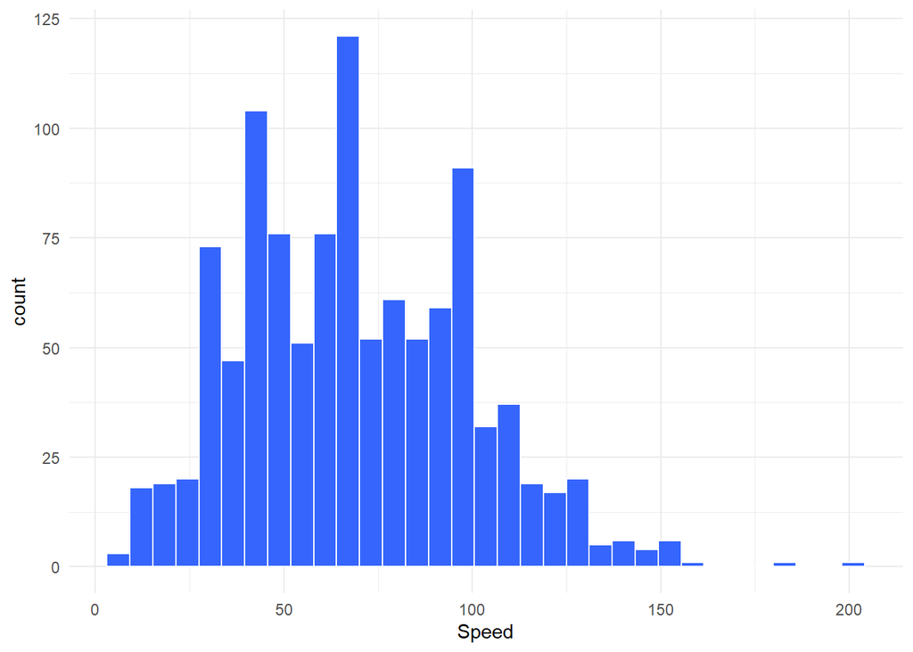

```r
# Creamos un histograma a partir de los datos Speed.
pokemon |> ggplot(aes(Speed)) +
# Definimos el color y el número de barras que tendrá nuestro histograma. Calculamos el número de barras a través de la raíz cuadrada de nuestro número de datos.
  geom_histogram(fill = "#3565fc", bins = 33, col = "white") +
# Indicamos el tema.
  theme_minimal()
```

#### Tabla de frecuencia de Type_1

```r
# Creamos una tabla de frecuencias a partir del dataframe pokemon.
tabla_frecuencias <- pokemon|>
# Contamos los intervalos que hay y creamos la frecuencia relativa, la frecuencia acumulada, la frecuencia relativa acumulada.
 count(Type_1) |>
  mutate(f = n/nrow(pokemon),
   N = cumsum(n),
    F = cumsum(f))
#Pintamos y definimos el número de decimales queremos que tenga nuestra tabla
knitr::kable(tabla_frecuencias, digits = 3)
```

| Type_1 | n | f | N | F |
| --- | --- | --- | --- | --- |
| Bug | 83 | 0.077 | 83 | 0.077 |
| Dark | 48 | 0.045 | 131 | 0.122 |
| Dragon | 41 | 0.038 | 172 | 0.160 |
| Electric | 63 | 0.059 | 235 | 0.219 |
| Fairy | 23 | 0.021 | 258 | 0.241 |
| Fighting | 45 | 0.042 | 303 | 0.283 |
| Fire | 67 | 0.062 | 370 | 0.345 |
| Flying | 9 | 0.008 | 379 | 0.354 |
| Ghost | 43 | 0.040 | 422 | 0.394 |
| Grass | 95 | 0.089 | 517 | 0.482 |
| Ground | 42 | 0.039 | 559 | 0.521 |
| Ice | 38 | 0.035 | 597 | 0.557 |
| Normal | 117 | 0.109 | 714 | 0.666 |
| Poison | 42 | 0.039 | 756 | 0.705 |
| Psychic | 80 | 0.075 | 836 | 0.780 |
| Rock | 60 | 0.056 | 896 | 0.836 |
| Steel | 39 | 0.036 | 935 | 0.872 |
| Water | 137 | 0.128 | 1072 | 1.000 |

#### Tabla de frecuencia de Type_2

```r
# Creamos una tabla de frecuencias a partir del dataframe pokemon.
tabla_frecuencias <- pokemon|>
# Contamos los intervalos que hay y creamos la frecuencia relativa, la frecuencia acumulada, la frecuencia relativa acumulada.
 count(Type_2) |>
  mutate(f = n/nrow(pokemon),
   N = cumsum(n),
    F = cumsum(f))
#Pintamos y definimos el número de decimales queremos que tenga nuestra tabla
knitr::kable(tabla_frecuencias, digits = 3)
```

| Type_2 | n | f | N | F |
| --- | --- | --- | --- | --- |
| Bug | 10 | 0.009 | 10 | 0.009 |
| Dark | 28 | 0.026 | 38 | 0.035 |
| Dragon | 35 | 0.033 | 73 | 0.068 |
| Electric | 11 | 0.010 | 84 | 0.078 |
| Fairy | 44 | 0.041 | 128 | 0.119 |
| Fighting | 32 | 0.030 | 160 | 0.149 |
| Fire | 18 | 0.017 | 178 | 0.166 |
| Flying | 114 | 0.106 | 292 | 0.272 |
| Ghost | 26 | 0.024 | 318 | 0.297 |
| Grass | 29 | 0.027 | 347 | 0.324 |
| Ground | 39 | 0.036 | 386 | 0.360 |
| Ice | 19 | 0.018 | 405 | 0.378 |
| Normal | 11 | 0.010 | 416 | 0.388 |
| Poison | 41 | 0.038 | 457 | 0.426 |
| Psychic | 43 | 0.040 | 500 | 0.466 |
| Rock | 16 | 0.015 | 516 | 0.481 |
| Steel | 36 | 0.034 | 552 | 0.515 |
| Water | 21 | 0.020 | 573 | 0.535 |
| NA | 499 | 0.465 | 1072 | 1.000 |

### Gráficos de barras

#### Tipos de Pokémon

Vamos ahora a ayudarnos de un gráfico de barras para analizar la cantidad de apariciones de cada tipo en el conjunto de todos los Pokémon, para concluir cuáles son los tipos más comunes.

```r
# Agrupar los tipos de Pokémon
pokemon_long <- pokemon %>%
  # Convertir en formato largo para contar ambos tipos
  pivot_longer(cols = c(Type_1, Type_2), names_to = "Type", values_to = "Types") %>%
  # Eliminar los NA, que representan Pokémon que no tienen segundo tipo
  filter(!is.na(Types))
```

Una vez agrupadas y contadas todas las ocurrencias de cada tipo, se procede a crear el gráfico.

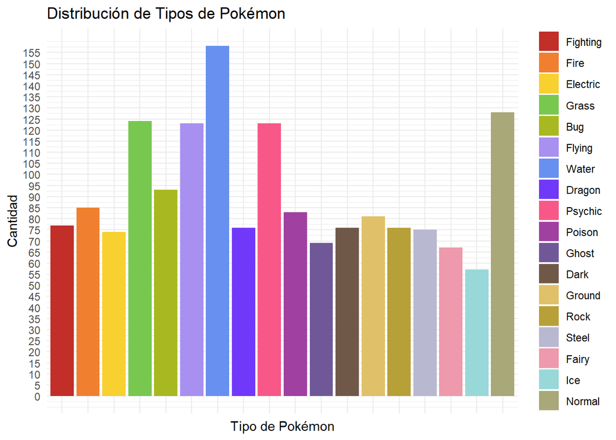

```r
# Crear los gráficos de barras, uno por cada generación, con colores personalizados
ggplot(pokemon_by_type, aes(x = Types, y = count, fill = Types)) +
  geom_bar(stat = "identity") +
  scale_fill_manual(values = colors) +  # Aplicar la paleta de colores personalizada
  scale_y_continuous(breaks = seq(0, max(pokemon_by_type$count), by = 5)) +  # Ajustar el eje Y
  labs(title = "Distribución de Tipos de Pokémon",
       x = "Tipo de Pokémon",
       y = "Cantidad") +
  theme_minimal() +
  theme(axis.text.x = element_blank(),  # Eliminar el texto del eje x
        axis.ticks.x = element_blank(),  # Eliminar las marcas del eje x
        strip.text = element_text(size = 12),  # Tamaño de los títulos de las facetas (Generación)
        panel.spacing = unit(2, "lines"),  # Aumentar el espacio entre gráficos
        legend.title = element_blank())  # Eliminar el título de la leyenda
```

Se puede observar que los Pokémon tipo Water son los más comunes con diferencia, seguidos de los tipos Grass, Flying, Psychic y Normal. El resto de tipos de Pokémon más o menos se encuentran equilibrados entre ellos.

#### Top 100 tipos más usados

A continuación, se analiza la cantidad de apariciones de cada tipo Pokémon en el top 100 Pokémon más usados en el ámbito competitivo:

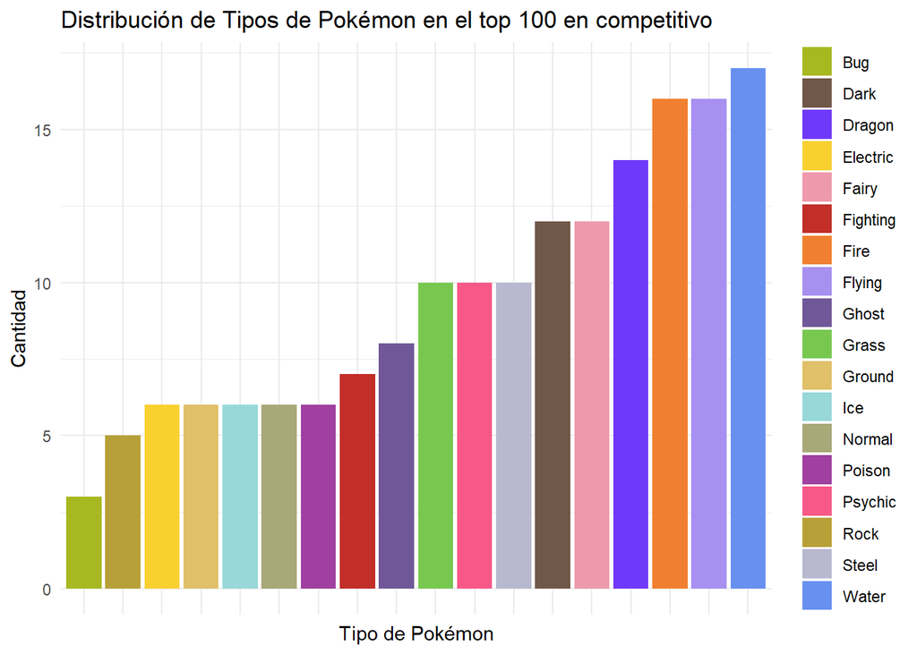

```r
  # Agrupar los tipos de Pokémon
  top100usage <- head(pokemon_by_usage,100) %>%
  # Convertir en formato largo para contar ambos tipos
  pivot_longer(cols = c(Type_1, Type_2), names_to = "Type", values_to = "Types") %>%
  # Eliminar los NA, que representan Pokémon que no tienen segundo tipo
  filter(!is.na(Types))

  pokemon_by_use <- top100usage %>%
  group_by(Types) %>%
  summarise(count = n()) %>%
  ungroup()

  ggplot(pokemon_by_use, aes(x = reorder(Types, count), y = count, fill = Types)) +
  geom_bar(stat = "identity") +

  scale_fill_manual(values = colors) +  # Aplicar la paleta de colores personalizada
  scale_y_continuous(breaks = seq(0, max(pokemon_by_use$count), by = 5)) +  # Ajustar el eje Y
  labs(title = "Distribución de Tipos de Pokémon en el top 100 en competitivo",
       x = "Tipo de Pokémon",
       y = "Cantidad") +
  theme_minimal() +
  theme(axis.text.x = element_blank(),  # Eliminar el texto del eje x
        axis.ticks.x = element_blank(),  # Eliminar las marcas del eje x
        strip.text = element_text(size = 12),  # Tamaño de los títulos de las facetas (Generación)
        panel.spacing = unit(2, "lines"),  # Aumentar el espacio entre gráficos
        legend.title = element_blank())  # Eliminar el título de la leyenda
```

Podemos apreciar la gran disparidad entre uso de cada tipo Pokémon. Lógicamente, podemos concluir que, generalmente, los tipos Pokémon más usados (Water, Fire, Flying…) tienen una ventaja intrínseca, ya sea por sus interacciones entre otros tipos, u otras razones, sobre los tipos Pokémon menos usados (Bug, Rock, Electric…)

### Gráfico de líneas

A continuación, en el gráfico se muestra la variación de la cantidad de Pokémon legendarios entre generaciones, además de la media y la mediana. Estos datos servirán luego para poder crear una predicción de la posible 9ª generación de Pokémon.

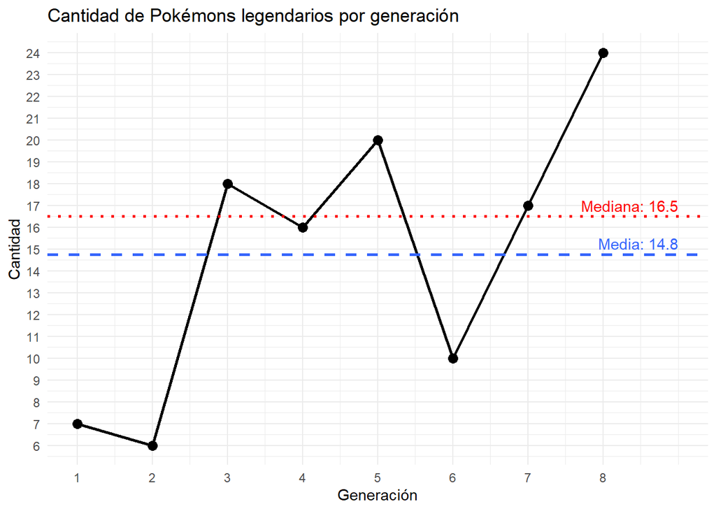

```r
# Agrupar los Pokémons legendarios
legendarios <- pokemon %>%
  filter(Legendary == TRUE) %>%
  group_by(Generation) %>%
  summarise(count = n())

# Calcular media y mediana
media <- mean(legendarios$count)
mediana <- median(legendarios$count)

# Crear el gráfico de líneas
ggplot(legendarios, aes(x = Generation, y = count)) +
  geom_line(color = "black", linewidth  = 1) +
  geom_point(size = 3, color = "black") +

  # Agregar líneas para media y mediana
  geom_hline(yintercept = media, color = "#3565fc", linetype = "dashed", linewidth = 1) +
  geom_hline(yintercept = mediana, color = "red", linetype = "dotted", linewidth = 1) +

  # Agregar etiquetas para media y mediana
  annotate("text", x = max(legendarios$Generation) + 1, y = media + 0.5,
           label = paste("Media:", round(media, 1)), color = "#3565fc", hjust = 1) +
  annotate("text", x = max(legendarios$Generation) + 1, y = mediana + 0.5,
           label = paste("Mediana:", round(mediana, 1)), color = "red", hjust = 1) +

  # Ajustes en los ejes del gráfico
  scale_x_continuous(breaks = seq(min(legendarios$Generation), max(legendarios$Generation), by = 1)) +
  scale_y_continuous(breaks = seq(min(legendarios$count), max(legendarios$count), by = 1)) +
  labs(title = "Cantidad de Pokémons legendarios por generación",
       x = "Generación",
       y = "Cantidad") +

  theme_minimal()
```

En general, se observa una tendencia al alza en el número de Pokémon legendarios por generación, con picos significativos en las generaciones 5 y 8, lo que indica que no existe una fórmula fija a la hora de introducir nuevos Pokémon legendarios.

### Resúmenes numéricos

#### Pokémons por generación

```r
# Tabla con los pokémon por generación
tabla_generacion_pokemons <- pokemon %>%
  group_by(Generation) %>%
  summarise(Pokemons_Por_Generacion = n()) %>%
  as.data.frame()  # Convertimos a data frame para evitar <dbl> e <int>

# Calcular la media total de pokémon por generación
media_total_pokemons <- mean(tabla_generacion_pokemons$Pokemons_Por_Generacion)

# Mostramos la tabla con los pokémon por generación
print(tabla_generacion_pokemons)
```

```
##   Generation Pokemons_Por_Generacion
## 1          1                     178
## 2          2                     106
## 3          3                     160
## 4          4                     121
## 5          5                     166
## 6          6                      85
## 7          7                     116
## 8          8                     140
```

```r
# Mostramos la media total separada
print(media_total_pokemons)
```

```
## [1] 134
```

#### Análisis descriptivo de las estadísticas globales

```r
pokemon_stats <- pokemon %>%
  select(HP,Attack, Defense, Sp_attack, Sp_defense, Speed)
summary_stats <- descr(pokemon_stats)

print(summary_stats)
```

```
## Descriptive Statistics
## pokemon_stats
## N: 1072
##
##                      Attack   Defense        HP   Sp_attack   Sp_defense     Speed
## ----------------- --------- --------- --------- ----------- ------------ ---------
##              Mean     80.94     74.97     70.49       73.27        72.48     68.79
##           Std.Dev     32.46     31.21     26.87       32.64        27.93     30.08
##               Min      5.00      5.00      1.00       10.00        20.00      5.00
##                Q1     56.00     52.00     50.00       50.00        50.00     45.00
##            Median     80.00     70.00     68.00       65.00        70.00     65.00
##                Q3    100.00     90.00     84.00       95.00        90.00     90.00
##               Max    190.00    250.00    255.00      194.00       250.00    200.00
##               MAD     30.39     29.65     25.20       31.13        29.65     32.62
##               IQR     44.00     38.00     34.00       45.00        40.00     45.00
##                CV      0.40      0.42      0.38        0.45         0.39      0.44
##          Skewness      0.46      1.14      1.76        0.71         0.92      0.42
##       SE.Skewness      0.07      0.07      0.07        0.07         0.07      0.07
##          Kurtosis     -0.05      2.84      7.91        0.19         2.36     -0.08
##           N.Valid   1072.00   1072.00   1072.00     1072.00      1072.00   1072.00
##         Pct.Valid    100.00    100.00    100.00      100.00       100.00    100.00
```

#### Análisis descriptivo de las estadísticas según generación

```r
with(pokemon, stby(HP,Generation, descr))
```

```
## Descriptive Statistics
## HP by Generation
## Data Frame: pokemon
## N: 178
##
##                          1        2        3        4        5        6        7        8
## ----------------- -------- -------- -------- -------- -------- -------- -------- --------
##              Mean    66.56    71.21    66.54    73.08    71.84    69.88    69.79    76.54
##           Std.Dev    28.79    30.59    24.06    25.11    22.35    26.10    27.09    29.97
##               Min    10.00    20.00     1.00    20.00    30.00    38.00    10.00    25.00
##                Q1    48.00    50.00    50.00    55.00    55.00    54.00    50.50    58.00
##            Median    62.00    70.00    65.00    70.00    70.00    65.00    69.00    70.00
##                Q3    80.00    90.00    80.00    85.00    85.00    80.00    80.00    95.00
##               Max   250.00   255.00   170.00   150.00   165.00   216.00   223.00   255.00
##               MAD    25.20    29.65    22.24    22.24    22.24    22.24    22.24    29.65
##               IQR    31.50    37.50    30.00    30.00    30.00    26.00    29.25    37.00
##                CV     0.43     0.43     0.36     0.34     0.31     0.37     0.39     0.39
##          Skewness     1.97     2.49     0.94     0.81     0.79     2.36     1.79     1.97
##       SE.Skewness     0.18     0.23     0.19     0.22     0.19     0.26     0.22     0.20
##          Kurtosis     8.83    12.07     2.46     0.76     0.85     9.84     7.63     8.99
##           N.Valid   178.00   106.00   160.00   121.00   166.00    85.00   116.00   140.00
##         Pct.Valid   100.00   100.00   100.00   100.00   100.00   100.00   100.00   100.00
```

```r
with(pokemon, stby(Attack,Generation, descr))
```

```
## Descriptive Statistics
## Attack by Generation
## Data Frame: pokemon
## N: 178
##
##                          1        2        3        4        5        6        7        8
## ----------------- -------- -------- -------- -------- -------- -------- -------- --------
##              Mean    77.06    72.03    81.62    82.87    82.14    77.19    86.11    86.73
##           Std.Dev    30.63    32.71    36.59    32.78    30.29    29.83    32.64    31.62
##               Min     5.00    10.00    15.00     5.00    25.00    22.00    20.00    20.00
##                Q1    55.00    50.00    53.00    62.00    55.00    54.00    61.00    64.50
##            Median    75.00    73.50    75.00    80.00    80.00    70.00    80.00    85.50
##                Q3    95.00    90.00   100.00   103.00   103.00   100.00   112.50   110.00
##               Max   190.00   185.00   180.00   170.00   170.00   160.00   181.00   170.00
##               MAD    29.65    31.88    37.06    29.65    35.58    29.65    37.06    34.84
##               IQR    40.00    40.00    46.00    41.00    46.75    46.00    50.75    45.25
##                CV     0.40     0.45     0.45     0.40     0.37     0.39     0.38     0.36
##          Skewness     0.56     0.63     0.63     0.31     0.33     0.77     0.32     0.13
##       SE.Skewness     0.18     0.23     0.19     0.22     0.19     0.26     0.22     0.20
##          Kurtosis     0.46     0.72    -0.14    -0.06    -0.58     0.20    -0.42    -0.51
##           N.Valid   178.00   106.00   160.00   121.00   166.00    85.00   116.00   140.00
##         Pct.Valid   100.00   100.00   100.00   100.00   100.00   100.00   100.00   100.00
```

El ataque, contrario a la vida, tendrá su máximo decayendo con cada generación, lo que generará una mayor simetría, medida por el Skewness (coeficiente de asimetría).

```r
with(pokemon, stby(Defense,Generation, descr))
```

```
## Descriptive Statistics
## Defense by Generation
## Data Frame: pokemon
## N: 178
##
##                          1        2        3        4        5        6        7        8
## ----------------- -------- -------- -------- -------- -------- -------- -------- --------
##              Mean    70.78    73.39    74.10    78.13    72.39    77.02    78.72    78.46
##           Std.Dev    28.30    39.23    35.22    30.15    23.26    31.20    32.13    31.06
##               Min     5.00    10.00    20.00     5.00    30.00    33.00    20.00    20.00
##                Q1    50.00    45.00    50.00    51.00    55.00    57.00    55.00    55.00
##            Median    66.00    70.00    67.50    72.00    70.00    70.00    75.00    75.00
##                Q3    85.00    90.00    90.00   105.00    90.00    90.00    97.50    99.50
##               Max   180.00   230.00   230.00   168.00   145.00   184.00   211.00   250.00
##               MAD    24.46    31.13    31.13    34.10    25.95    25.20    30.39    29.65
##               IQR    35.00    44.25    40.00    54.00    34.75    33.00    42.25    44.25
##                CV     0.40     0.53     0.48     0.39     0.32     0.41     0.41     0.40
##          Skewness     0.85     1.54     1.33     0.29     0.59     1.11     0.83     1.40
##       SE.Skewness     0.18     0.23     0.19     0.22     0.19     0.26     0.22     0.20
##          Kurtosis     1.56     3.73     2.60    -0.55     0.03     0.86     1.25     5.21
##           N.Valid   178.00   106.00   160.00   121.00   166.00    85.00   116.00   140.00
##         Pct.Valid   100.00   100.00   100.00   100.00   100.00   100.00   100.00   100.00
```

```r
with(pokemon, stby(Sp_attack,Generation, descr))
```

```
## Descriptive Statistics
## Sp_attack by Generation
## Data Frame: pokemon
## N: 178
##
##                          1        2        3        4        5        6        7        8
## ----------------- -------- -------- -------- -------- -------- -------- -------- --------
##              Mean    72.11    65.94    75.81    76.40    71.92    75.26    74.34    74.22
##           Std.Dev    34.01    27.81    35.41    31.91    31.81    32.45    35.54    29.88
##               Min    15.00    10.00    10.00    10.00    15.00    27.00    10.00    15.00
##                Q1    45.00    40.00    50.00    54.00    45.00    50.00    50.00    51.50
##            Median    65.00    65.00    70.00    71.00    65.00    65.00    65.50    70.00
##                Q3    95.00    85.00    95.00   100.00    95.00    97.00    97.50    93.00
##               Max   194.00   165.00   180.00   150.00   170.00   170.00   173.00   165.00
##               MAD    29.65    29.65    34.10    35.58    29.65    28.17    37.81    29.65
##               IQR    50.00    44.50    45.00    46.00    49.25    47.00    47.25    39.75
##                CV     0.47     0.42     0.47     0.42     0.44     0.43     0.48     0.40
##          Skewness     0.85     0.65     0.80     0.29     0.64     0.93     0.64     0.56
##       SE.Skewness     0.18     0.23     0.19     0.22     0.19     0.26     0.22     0.20
##          Kurtosis     0.59     0.52     0.39    -0.73    -0.35     0.32    -0.28    -0.11
##           N.Valid   178.00   106.00   160.00   121.00   166.00    85.00   116.00   140.00
##         Pct.Valid   100.00   100.00   100.00   100.00   100.00   100.00   100.00   100.00
```

```r
with(pokemon, stby(Sp_defense,Generation, descr))
```

```
## Descriptive Statistics
## Sp_defense by Generation
## Data Frame: pokemon
## N: 178
##
##                          1        2        3        4        5        6        7        8
## ----------------- -------- -------- -------- -------- -------- -------- -------- --------
##              Mean    69.71    73.91    71.22    77.19    68.82    75.20    73.88    73.79
##           Std.Dev    25.39    31.53    31.04    27.50    22.34    29.65    28.01    29.26
##               Min    20.00    20.00    20.00    30.00    25.00    25.00    25.00    20.00
##                Q1    50.00    55.00    50.00    55.00    50.00    55.00    50.00    53.50
##            Median    70.00    65.00    65.00    75.00    65.00    71.00    70.50    70.00
##                Q3    85.00    95.00    87.00   100.00    85.00    89.00    95.00    90.00
##               Max   130.00   230.00   200.00   150.00   135.00   154.00   142.00   250.00
##               MAD    29.65    28.17    25.95    32.62    22.24    23.72    30.39    29.65
##               IQR    35.00    40.00    37.00    45.00    34.25    34.00    45.00    36.25
##                CV     0.36     0.43     0.44     0.36     0.32     0.39     0.38     0.40
##          Skewness     0.08     1.49     0.99     0.28     0.55     0.95     0.34     1.76
##       SE.Skewness     0.18     0.23     0.19     0.22     0.19     0.26     0.22     0.20
##          Kurtosis    -0.73     4.49     1.51    -0.79    -0.10     0.53    -0.59     7.81
##           N.Valid   178.00   106.00   160.00   121.00   166.00    85.00   116.00   140.00
##         Pct.Valid   100.00   100.00   100.00   100.00   100.00   100.00   100.00   100.00
```

Ambas tablas de ataque y defensa especial estarán en consonancia con las estadísticas correspondientes, reforzando la idea de que estas variables están proporcionalmente relacionadas, como se comprobará a continuación.

```r
with(pokemon, stby(Speed,Generation, descr))
```

```
## Descriptive Statistics
## Speed by Generation
## Data Frame: pokemon
## N: 178
##
##                          1        2        3        4        5        6        7        8
## ----------------- -------- -------- -------- -------- -------- -------- -------- --------
##              Mean    72.71    61.81    66.92    71.34    68.12    68.00    67.80    71.14
##           Std.Dev    29.18    27.26    31.33    28.48    28.64    26.78    31.23    34.83
##               Min    15.00     5.00    10.00     5.00    10.00    23.00     5.00    10.00
##                Q1    50.00    40.00    46.50    46.00    45.00    49.00    42.50    44.50
##            Median    70.00    60.50    65.00    77.00    65.00    62.00    65.00    70.00
##                Q3    90.00    85.00    87.50    91.00    95.00    84.00    92.50    94.50
##               Max   150.00   130.00   180.00   135.00   145.00   132.00   151.00   200.00
##               MAD    29.65    30.39    29.65    28.17    34.10    25.20    37.06    37.06
##               IQR    40.00    45.00    39.00    45.00    49.00    35.00    49.50    49.50
##                CV     0.40     0.44     0.47     0.40     0.42     0.39     0.46     0.49
##          Skewness     0.36     0.18     0.75    -0.06     0.13     0.49     0.39     0.62
##       SE.Skewness     0.18     0.23     0.19     0.22     0.19     0.26     0.22     0.20
##          Kurtosis    -0.35    -0.71     0.67    -0.86    -0.84    -0.63    -0.59     0.29
##           N.Valid   178.00   106.00   160.00   121.00   166.00    85.00   116.00   140.00
##         Pct.Valid   100.00   100.00   100.00   100.00   100.00   100.00   100.00   100.00
```

La velocidad varía de manera diferente a las demás estadísticas, llegando incluso a tener un coeficiente de asimetría negativo, algo que no había ocurrido hasta ahora. El valor mínimo se mantendrá constante en el tiempo, mientras que el máximo fluctúa sin seguir un patrón claro.

## 4.2 Datos bivariantes

### Gráfico de barras de tipos de Pokémon por generación

A continuación, se va a analizar la cantidad de apariciones de cada tipo de Pokémon en cada generación, con el objetivo de diferenciar las cantidades entre tipos y entre cada juego. Se espera que en las primeras generaciones las cantidades entre tipos, sean más dispares y que los valores se estabilicen según avancen las generaciones, porque es lógico que el equilibrio al comienzo sea menos importante, que según se iban creando más y más generaciones. También se espera que, si hay un crecimiento repentino de un tipo en una generación, en la siguiente haya un descenso igual de importante, para compensar por la disparidad anterior.

```r
# Agrupar los tipos de Pokémon
pokemon_long <- pokemon %>%
  # Convertir en formato largo para contar ambos tipos
  pivot_longer(cols = c(Type_1, Type_2), names_to = "Type", values_to = "Types") %>%
  # Eliminar los NA, que representan Pokémon que no tienen segundo tipo
  filter(!is.na(Types))

# Agrupar por generación y tipo de Pokémon, contando las ocurrencias
pokemon_by_type <- pokemon_long %>%
  group_by(Generation, Types) %>%
  summarise(count = n(), .groups = "drop")
```

Una vez agrupadas y contadas todas las ocurrencias de cada tipo, se procede a crear el gráfico.

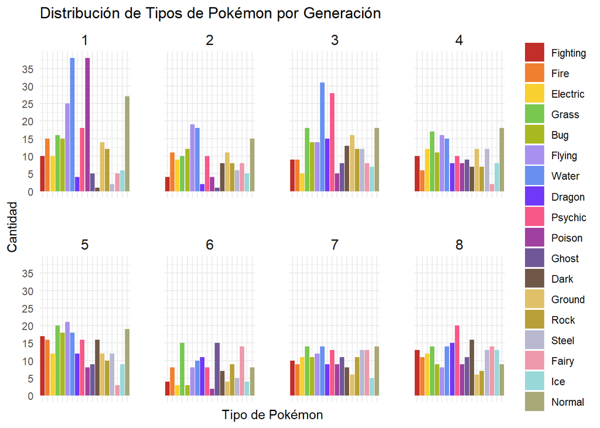

```r
# Crear los gráficos de barras, uno por cada generación, con colores personalizados
ggplot(pokemon_by_type, aes(x = Types, y = count, fill = Types)) +
  geom_bar(stat = "identity") +
  scale_fill_manual(values = colors) +  # Aplicar la paleta de colores personalizada
  scale_y_continuous(breaks = seq(0, max(pokemon_by_type$count), by = 5)) +  # Ajustar el eje Y
  facet_wrap(~ Generation, ncol = 4) +  # Distribuir en 4 columnas
  labs(title = "Distribución de Tipos de Pokémon por Generación",
       x = "Tipo de Pokémon",
       y = "Cantidad") +
  theme_minimal() +
  theme(axis.text.x = element_blank(),  # Eliminar el texto del eje x
        axis.ticks.x = element_blank(),  # Eliminar las marcas del eje x
        strip.text = element_text(size = 12),  # Tamaño de los títulos de las facetas (Generación)
        panel.spacing = unit(2, "lines"),  # Aumentar el espacio entre gráficos
        legend.title = element_blank())  # Eliminar el título de la leyenda
```

A partir de la cuarta generación en adelante, la cantidad de tipos tiende a estabilizarse. Sin embargo, las primeras generaciones muestran una mayor disparidad en los tipos, como en la primera, donde la cantidad de tipos Dark, Dragon o Ghost, y de Water o Poison, son muy dispares.

En general, se cumple la tendencia esperada: conforme avanzan las generaciones, la cantidad de Pokémon de cada tipo tiende a nivelarse, y que grandes picos van acompañados por grandes caídas, que luego se estabilizan.

### Boxplots

#### Gráfico de cajas HP y Generación

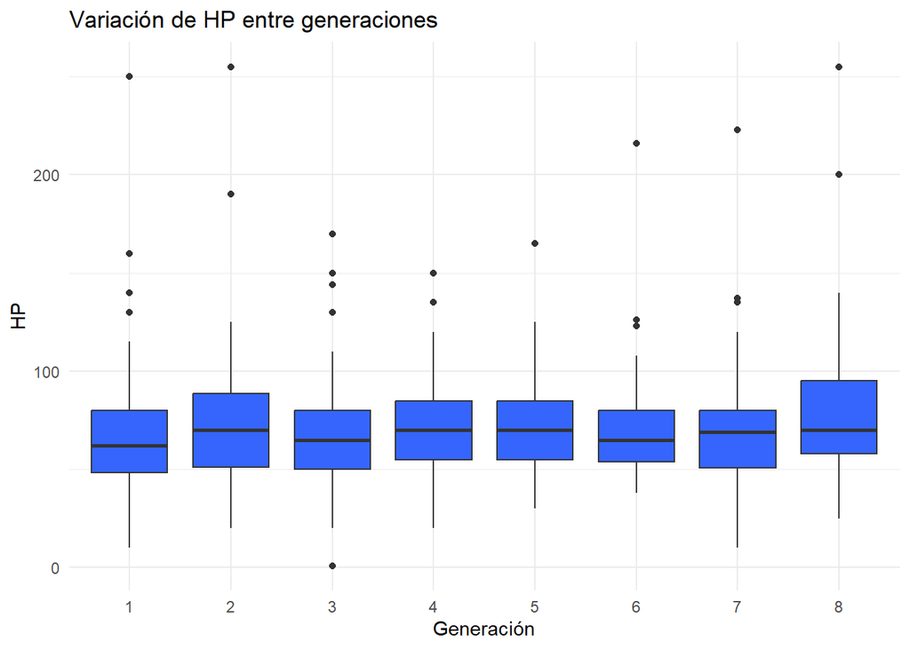

```r
# Definimos el dataframe Pokémon, definiremos el estilo del blox pot y a continuación indicaremos que datos debe tener cada variable , y le asignaremos un nombre.
pokemon |> ggplot(aes(y=HP , x=factor(Generation))) +
  geom_boxplot(fill = "#3565fc") +
  labs(title = "Variación de HP entre generaciones",
       x="Generación") +
  theme_minimal()
```

En este gráfico de cajas compara la estadística de HP con el número de generación de los Pokémon. Podemos observar que la mediana es similar y siempre se encuentra por debajo de 100. También podemos notar que en todas las generaciones hay Pokémon que se salen de la norma y están por encima de 100 HP; por el contrario, solo vemos un caso atípico por debajo de 100, situado en la tercera generación. Podemos concluir que la octava generación es la que tiene el mayor HP, ya que muestra una mayor concentración de valores cercanos a los niveles superiores, teniendo la caja más alta y teniendo valores atípicos que superan los 200.

#### Gráfico de cajas Attack y Generación

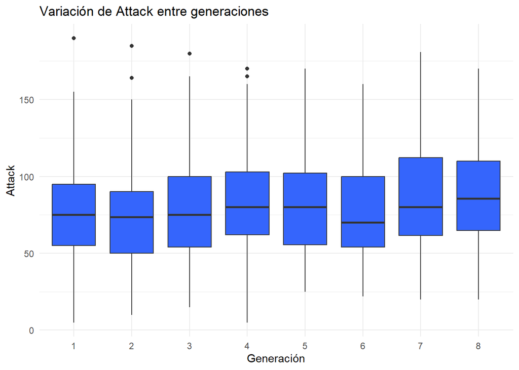

```r
pokemon |> ggplot(aes(y=Attack , x=factor(Generation))) +
  geom_boxplot(fill = "#3565fc") +
  labs(title = "Variación de Attack entre generaciones",
       x="Generación") +
  theme_minimal()
```

En este gráfico de cajas compara la estadística de Attack con el número de generación de los Pokémon. Podemos observar que, desde la primera hasta la cuarta generación, hay casos atípicos que superan los 150 puntos de Attack. Sin embargo, a partir de la cuarta generación, estos valores atípicos desaparecen. Aunque todas las generaciones presentan un rango de dispersión similar, podemos concluir que la octava generación es la que tiene el mayor Attack, ya que muestra una mayor concentración de valores cercanos a los niveles superiores teniendo la caja más alta. Además, no se observan valores atípicos en esta generación, lo que indica que los datos están consistentemente concentrados en un rango más alto.

#### Gráfico de cajas Defense y Generación

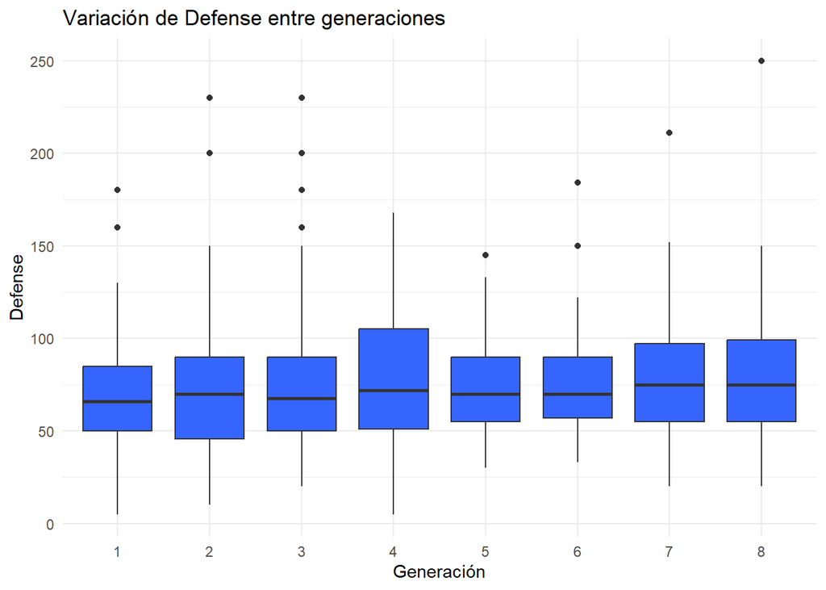

```r
pokemon |> ggplot(aes(y=Defense , x=factor(Generation))) +
  geom_boxplot(fill = "#3565fc") +
  labs(title = "Variación de Defense entre generaciones",
       x="Generación") +
  theme_minimal()
```

#### Gráfico de cajas Sp_attack y Generación

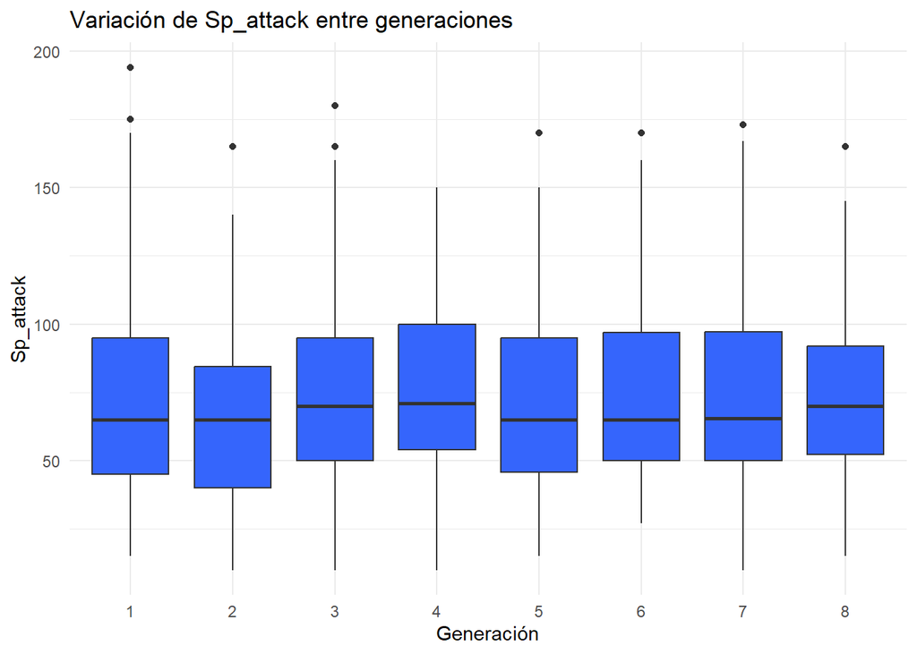

```r
pokemon |> ggplot(aes(y=Sp_attack , x=factor(Generation))) +
  geom_boxplot(fill = "#3565fc") +
  labs(title = "Variación de Sp_attack entre generaciones",
       x="Generación") +
  theme_minimal()
```

Este gráfico de cajas compara la estadística de Sp_attack con el número de generación de los Pokémon. Podemos observar que, en todas las generaciones, excepto en la cuarta, hay casos atípicos que superan los 150 puntos de Sp_attack.

La cuarta generación es la que presenta una Sp_attack mayor, ya que su caja es ligeramente más alta que las demás, lo que indica una mayor dispersión de datos y una mediana más elevada.

#### Gráfico de cajas Sp_defense y Generación

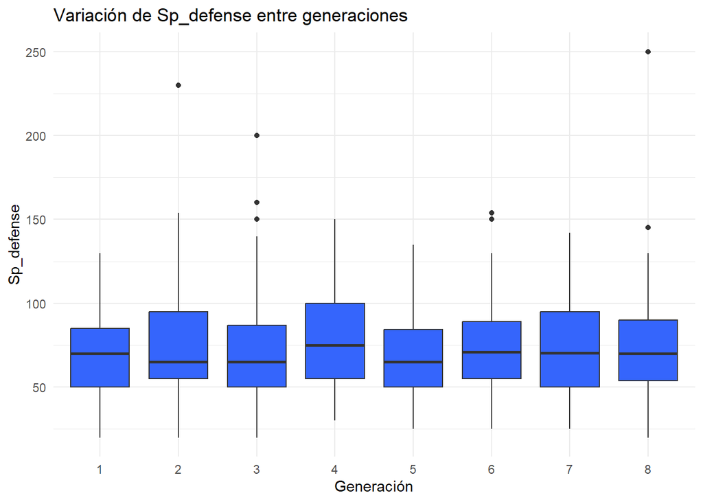

```r
pokemon|> ggplot(aes(y=Sp_defense , x=factor(Generation))) +
  geom_boxplot(fill = "#3565fc") +
  labs(title = "Variación de Sp_defense entre generaciones",
       x="Generación") +
  theme_minimal()
```

Este gráfico de cajas compara la estadística de Sp_defense con el número de generación de los Pokémon. Podemos observar que en las generaciones 2,3,6 y 8 hay casos atípicos que superan los 150 puntos de Sp_defense y en la 2 y 8 llegando a superar los 200.

La cuarta generación es la que presenta una Sp_defense mayor, ya que su caja es ligeramente más alta que las demás, lo que indica una mayor dispersión de datos y una mediana más elevada.

#### Gráfico de cajas Speed y Generación

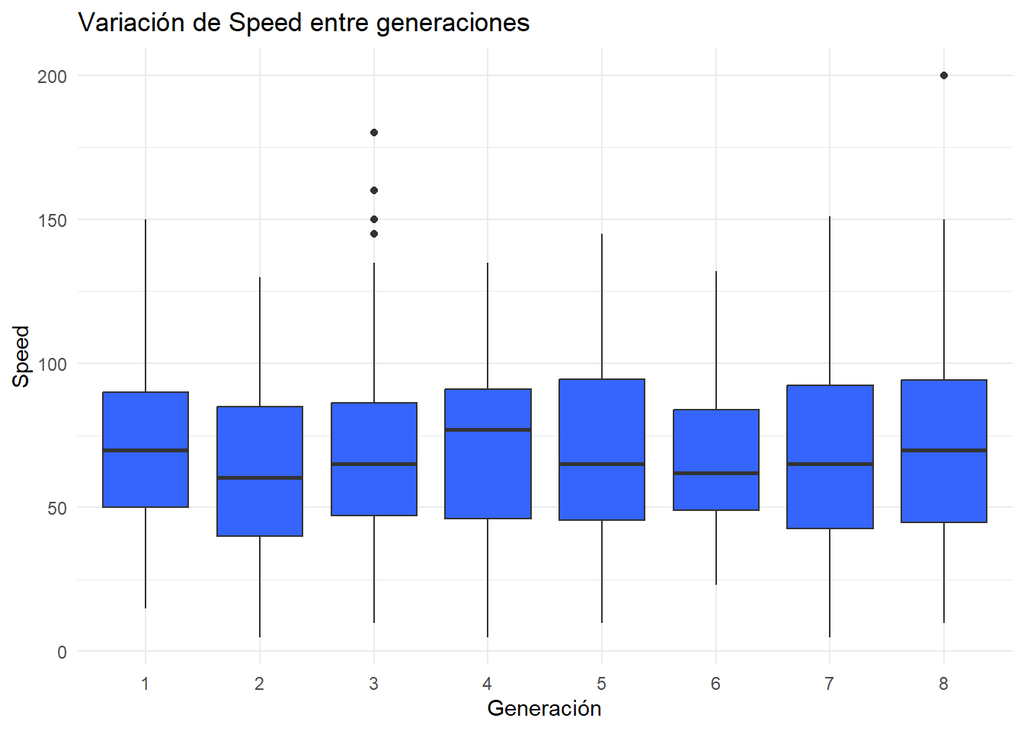

```r
pokemon|> ggplot(aes(y=Speed , x=factor(Generation))) +
  geom_boxplot(fill = "#3565fc") +
  labs(title = "Variación de Speed entre generaciones",
       x="Generación") +
  theme_minimal()
```

Este gráfico de cajas compara la estadística de Speed con el número de generación de los Pokémon. Podemos observar que en las generaciones 3 y 8 hay casos atípicos viendo que en la 3 hay más cantidad que en la 8.

### Scatter plot

En este apartado analizaremos la posible existencia de correlación entre estadísticas de cualidades similares de los Pokémon, con el fin de verificar si están relacionadas directa o indirectamente.

#### Correlación entre Attack vs. Sp_attack

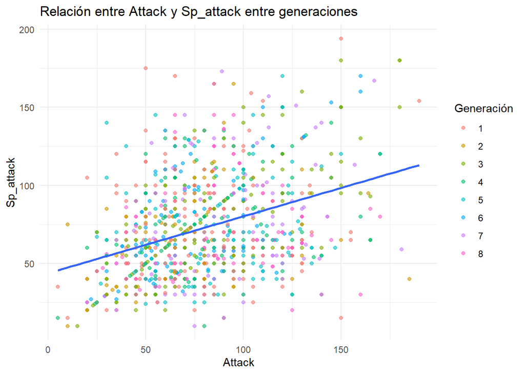

```r
# Crear el scatterplot con colores por generación
ggplot(pokemon, aes(x = Attack, y = Sp_attack, color = as.factor(Generation))) +
  geom_point(alpha = 0.6) +
  geom_smooth(method = "lm", color = "#3565fc", se = FALSE) +  # Línea de regresión
  # Gráfico de dispersión
  labs(title = "Relación entre Attack y Sp_attack entre generaciones",
       x = "Attack",
       y = "Sp_attack",
       color = "Generación") +
  theme_minimal()
```

```r
# Calcular y mostrar la correlación
correlation <- cor(pokemon$Attack, pokemon$Sp_attack, use = "complete.obs")
# Calcular correlación
print(paste("Correlación entre Attack y Sp_attack:", round(correlation, 2)))
```

```
## [1] "Correlación entre Attack y Sp_attack: 0.36"
```

El análisis muestra que existe una relación positiva pero débil entre el ataque físico y el ataque especial de los Pokémon. Esto indica que, en general, un Pokémon con un valor alto de Attack tiende a tener también un valor alto de Sp_Attack, pero no es una regla estricta, y hay bastante variabilidad entre los individuos. Además, la correlación moderada y la dispersión reflejan que ciertos Pokémon están especializados en uno de estos tipos de ataque, dependiendo de su tipo o rol en las batallas.

#### Correlación entre Defense vs. Sp_defense

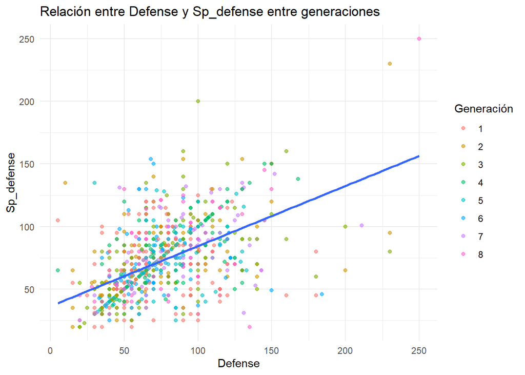

```r
# Crear el scatterplot
ggplot(pokemon, aes(x = Defense, y = Sp_defense, color = as.factor(Generation))) +
  geom_point(alpha = 0.6) +
  geom_smooth(method = "lm", color = "#3565fc", se = FALSE) +
  # Gráfico de dispersión
  labs(title = "Relación entre Defense y Sp_defense entre generaciones",
       x = "Defense",
       y = "Sp_defense",
       color = "Generación") +
  theme_minimal()
```

```r
# Calcular y mostrar la correlación
correlation <- cor(pokemon$Defense, pokemon$Sp_defense, use = "complete.obs")
# Calcular correlación
print(paste("Correlación entre Defense y Sp_defense:", round(correlation, 2)))
```

```
## [1] "Correlación entre Defense y Sp_defense: 0.54"
```

Al igual que en la correlación anterior, el análisis muestra que existe una relación moderada positiva entre las variables. Sin embargo, esta relación no es lo suficientemente fuerte como para ser considerada una relación lineal clara. También, es importante considerar otras variables que podrían estar en juego, como el tipo de Pokémon, la evolución, o incluso el nivel. Por lo que, la correlación no implica causalidad.

### Gráfico de regresión

#### Covarianza entre Stat_Average vs. Usage_Percentage

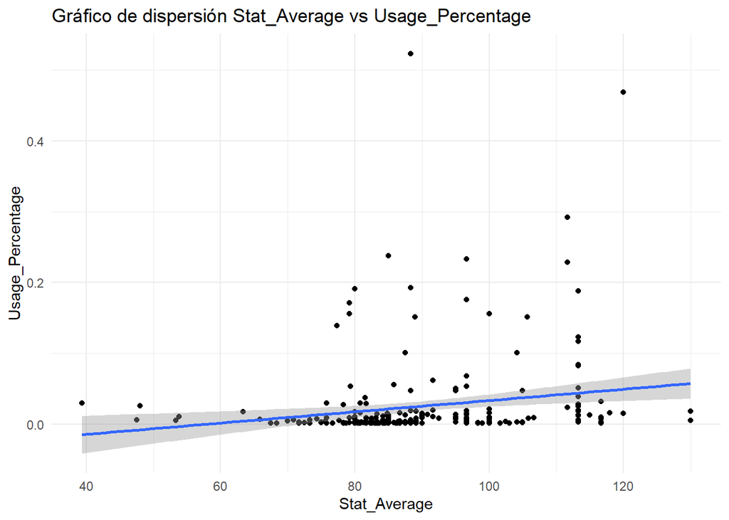

```r
#STAT_AVERAGE VS USAGE

# Define ranges for x and y
Stat_range <- c(5, 131)
Usage_range <- c(0.001, 100)

# Filter data based on the defined ranges
filtered_data <- pokemon %>% select(Stat_Average, Usage_Percentage) %>%
  filter(Stat_Average >= Stat_range[1] & Stat_Average <= Stat_range[2],
         Usage_Percentage >= Usage_range[1] & Usage_Percentage <= Usage_range[2])


filtered_data|>

ggplot(aes(x = Stat_Average, y = Usage_Percentage)) +   geom_point() +

  geom_smooth(method = lm) +

  labs(title = "Gráfico de dispersión Stat_Average vs Usage_Percentage")+
  theme_minimal()
```

```r
model <- lm(Usage_Percentage ~ Stat_Average, data = filtered_data)
model_summary <- summary(model)

print(model_summary)
```

```
##
## Call:
## lm(formula = Usage_Percentage ~ Stat_Average, data = filtered_data)
##
## Residuals:
##      Min       1Q   Median       3Q      Max
## -0.05224 -0.02189 -0.01657 -0.00792  0.49916
##
## Coefficients:
##               Estimate Std. Error t value Pr(>|t|)
## (Intercept)  -0.046080   0.023227  -1.984  0.04820 *
## Stat_Average  0.000795   0.000256   3.105  0.00209 **
## ---
## Signif. codes:  0 '***' 0.001 '**' 0.01 '*' 0.05 '.' 0.1 ' ' 1
##
## Residual standard error: 0.06054 on 293 degrees of freedom
## Multiple R-squared:  0.03186,    Adjusted R-squared:  0.02855
## F-statistic: 9.642 on 1 and 293 DF,  p-value: 0.002088
```

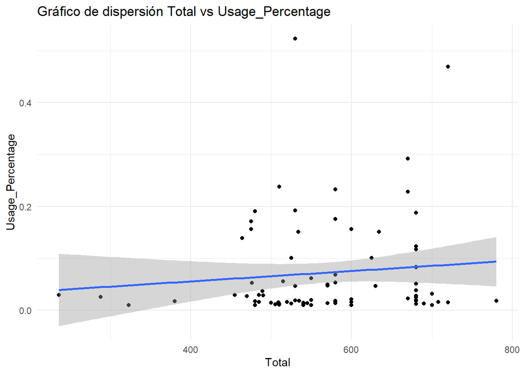

```r
#TOTAL VS USAGE

# Define ranges for x and y
Total_range <- c(5, 800)
Usage_range <- c(0.01, 100)

# Filter data based on the defined ranges
filtered_data <- pokemon %>% select(Total, Usage_Percentage) %>%
  filter(Total >= Total_range[1] & Total <= Total_range[2],
         Usage_Percentage >= Usage_range[1] & Usage_Percentage <= Usage_range[2])


filtered_data|>

ggplot(aes(x = Total, y = Usage_Percentage)) +   geom_point() +

  geom_smooth(method = lm) +

  labs(title = "Gráfico de dispersión Total vs Usage_Percentage")+
  theme_minimal()
```

```r
model <- lm(Usage_Percentage ~ Total, data = filtered_data)
model_summary <- summary(model)

print(model_summary)
```

```
##
## Call:
## lm(formula = Usage_Percentage ~ Total, data = filtered_data)
##
## Residuals:
##      Min       1Q   Median       3Q      Max
## -0.07573 -0.05542 -0.03634  0.03269  0.45450
##
## Coefficients:
##              Estimate Std. Error t value Pr(>|t|)
## (Intercept) 1.593e-02  5.853e-02   0.272    0.786
## Total       9.977e-05  1.020e-04   0.978    0.331
##
## Residual standard error: 0.09362 on 91 degrees of freedom
## Multiple R-squared:  0.0104, Adjusted R-squared:  -0.000475
## F-statistic: 0.9563 on 1 and 91 DF,  p-value: 0.3307
```

# 5. Conclusión

A lo largo de las generaciones, tanto los tipos de Pokémon como sus estadísticas han tendido a equilibrarse, evitando grandes picos de disparidad. Las variaciones entre las estadísticas individuales de los Pokémon de cada generación han sido relativamente consistentes, lo que sugiere que la tendencia hacia un equilibrio continuará en la 9ª generación.

A partir de todos los datos analizados, se puede hacer una estimación a valores generales y particulares.

## Valores generales

La media de Pokémon por generación es de 134, por lo que podemos esperar que la 9ª generación presente un número similar de nuevos Pokémon. De la misma manera, la media de los legendarios rondan los 15, por lo que se sugiere un número similar no muy lejano.

## Valores particulares

Según los gráficos de barras, los tipos de Pokémon se puede esperar que ronden los valores entre 20 y 10 por elemento, donde los más perjudicados, con valores menores, serán los tipos “Ground” y “Normal”.

En cuanto a las estadísticas básicas de los Pokémon:

- HP: 25% tendrá un rango de 20 a 60, 50% estará entre 60 y 90 y el último 25% estará entre 90 y 140. El máximo será cercano a 230.
- Attack: 25% tendrá un rango de 20 a 65, 50% estará entre 65 y 125 y el último 25% estará entre 125 y 170. Es probable que no haya casos que se salgan de los porcentajes.
- Defense: 25% tendrá un rango de 20 a 55, 50% estará entre 55 y 100 y el último 25% estará entre 100 y 150. El máximo será cercano a 230.
- Sp_Attack: 25% tendrá un rango de 15 a 65, 50% estará entre 65 y 95 y el último 25% estará entre 95 y 150. El máximo será cercano a 170.
- Sp_Defense: 25% tendrá un rango de 20 a 55, 50% estará entre 55 y 90 y el último 25% estará entre 90 y 130. El máximo será cercano a 175.
- Speed: 25% tendrá un rango de 10 a 55, 50% estará entre 55 y 90 y el último 25% estará entre 90 y 130. El máximo será cercano a 200.
- Finalmente, la mayoría de Pokémon caerán en un rango de estadísticas totales entre 270 y 550, con algunos casos particulares que salgan del rango.

# 6. Bibliografía

- https://www.smogon.com/stats/2022-04/gen8vgc2022-0.txt
- https://www.kaggle.com/datasets/jaidalmotra/pokemon-dataset